# LIME model agnostic explanations

# TP 2: Implementación LIME

## Objetivo

Explicar las bases del método de LIME que permite explicar modelos de caja negra. Entendimiento teórico del uso de modelos sustitutos locales que permiten la interpretabilidad de modelos de caja negra subyacentes. Entender el tipo de datos donde puede utilizarse esta técnica (texto, datos tabulados e imágenes). Algoritmos con el cual puede implementarse (árboles, regresión lineal regularizada con Lasso, etc.). Comprensión de su aplicación paso a paso en R utilizando el dataset seleccionado como ejemplo.

```r
library(tidyverse)
library(tidymodels)
library(caret)
library(GGally)
library(lime)
```

```r
## cargamos el dataset
df = read_csv("./heart.csv", progress = FALSE)
```

A partir de la documentacion del dataset sabemos que:

- Age: Edad del paciente
- Sex: Sexo biológico
- ChestPainType: Tipo de dolor de pecho (ATA: Angina atipica, NAP: Dolor no-anginal, ASY: Asintomatico, TA: Angina tipica)
- RestingBP: Presion sanguinea en reposo [mm Hg]
- Cholesterol: Colesterol en sangre [mm/dl]
- FastinBS: Glucemia en ayuno (1: Glucemia mayor a valor normal de 120mg/dl, 0 si valor normal)
- RestingECG: Interpretacion de los resultados de Electrocardiograma en reposo (Normal: normal, LVH: hipertrofia ventricular izquierda, ST: anormalidad en la onda ST-T del electrocardiograma)
- MaxHR: Maxima frecuencia cardiaca alcanzada
- ExcercisaAngina: Angina inducida por ejercicio (True, False)
- Oldpeak: Valor de la depresion de la onda ST del electrocardiograma
- ST_Slope: Pendiente del pico ST durante el ejercicio (Up: hacia arriba, Flat: chata, Down: hacia abajo) *HeartDisease: Condicion cardiaca

```r
## veo la estructura general
df %>% glimpse
```

```
Rows: 918
Columns: 12
$ Age            <dbl> 40, 49, 37, 48, 54, 39, 45, 54, 37, 48, 37, 58, 39, 49, 42, 54, 38, 43, 60, 36, 43, 44, 49, 44, 40, 36, 53, 52, 53, 51, 53, 56, 54, ~
$ Sex            <chr> "M", "F", "M", "F", "M", "M", "F", "M", "M", "F", "F", "M", "M", "M", "F", "F", "M", "F", "M", "M", "F", "M", "F", "M", "M", "M", "M~
$ ChestPainType  <chr> "ATA", "NAP", "ATA", "ASY", "NAP", "NAP", "ATA", "ATA", "ASY", "ATA", "NAP", "ATA", "ATA", "ASY", "NAP", "ATA", "ASY", "ATA", "ASY",~
$ RestingBP      <dbl> 140, 160, 130, 138, 150, 120, 130, 110, 140, 120, 130, 136, 120, 140, 115, 120, 110, 120, 100, 120, 100, 120, 124, 150, 130, 130, 12~
$ Cholesterol    <dbl> 289, 180, 283, 214, 195, 339, 237, 208, 207, 284, 211, 164, 204, 234, 211, 273, 196, 201, 248, 267, 223, 184, 201, 288, 215, 209, 26~
$ FastingBS      <dbl> 0, 0, 0, 0, 0, 0, 0, 0, 0, 0, 0, 0, 0, 0, 0, 0, 0, 0, 0, 0, 0, 0, 0, 0, 0, 0, 0, 0, 0, 0, 0, 0, 0, 0, 0, 0, 1, 0, 1, 0, 0, 0, 0, 0, ~
$ RestingECG     <chr> "Normal", "Normal", "ST", "Normal", "Normal", "Normal", "Normal", "Normal", "Normal", "Normal", "Normal", "ST", "Normal", "Normal", ~
$ MaxHR          <dbl> 172, 156, 98, 108, 122, 170, 170, 142, 130, 120, 142, 99, 145, 140, 137, 150, 166, 165, 125, 160, 142, 142, 164, 150, 138, 178, 112,~
$ ExerciseAngina <chr> "N", "N", "N", "Y", "N", "N", "N", "N", "Y", "N", "N", "Y", "N", "Y", "N", "N", "N", "N", "N", "N", "N", "N", "N", "Y", "N", "N", "Y~
$ Oldpeak        <dbl> 0.0, 1.0, 0.0, 1.5, 0.0, 0.0, 0.0, 0.0, 1.5, 0.0, 0.0, 2.0, 0.0, 1.0, 0.0, 1.5, 0.0, 0.0, 1.0, 3.0, 0.0, 1.0, 0.0, 3.0, 0.0, 0.0, 3.~
$ ST_Slope       <chr> "Up", "Flat", "Up", "Flat", "Up", "Up", "Up", "Up", "Flat", "Up", "Up", "Flat", "Up", "Flat", "Up", "Flat", "Flat", "Up", "Flat", "F~
$ HeartDisease   <dbl> 0, 1, 0, 1, 0, 0, 0, 0, 1, 0, 0, 1, 0, 1, 0, 0, 1, 0, 1, 1, 0, 0, 0, 1, 0, 0, 0, 0, 0, 0, 1, 0, 1, 1, 0, 0, 1, 0, 0, 0, 0, 1, 0, 0, ~
```

```r
## conteo de datos is.na por variable
df %>%
  select(everything()) %>%
  summarise_all(funs(sum(is.na(.))))
```

| Age | Sex | ChestPainType | RestingBP | Cholesterol | FastingBS | RestingECG | MaxHR | ExerciseAngina | Oldpeak | ST_Slope | HeartDisease |
| --- | --- | --- | --- | --- | --- | --- | --- | --- | --- | --- | --- |
| 0 | 0 | 0 | 0 | 0 | 0 | 0 | 0 | 0 | 0 | 0 | 0 |

```r
## muestro los valores unicos de cada columna no numerica
for (i in df %>% select(where(is.character)) %>% names){
  print(unique(df[i]))
}
```

| Sex |
| --- |
| M |
| F |

| ChestPainType |
| --- |
| ATA |
| NAP |
| ASY |
| TA |

| RestingECG |
| --- |
| Normal |
| ST |
| LVH |

| ExerciseAngina |
| --- |
| N |
| Y |

| ST_Slope |
| --- |
| Up |
| Flat |
| Down |

```r
## evaluo la relacion entre variables

df <- df %>% mutate(condicion_cardiaca = case_when
      (
      HeartDisease == 1 ~ "si",
      HeartDisease == 0 ~ "no",
      TRUE ~ "na"
      )
)
```

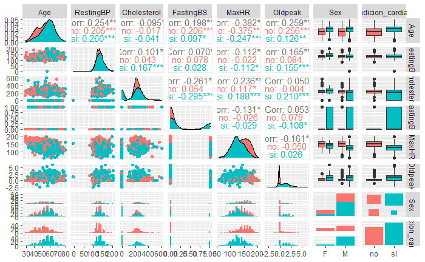

```r
# df %>% ggpairs(aes(color=condicion_cardiaca),  progress = FALSE)
df %>% select(-HeartDisease) %>% select(where(is.numeric) | Sex | condicion_cardiaca) %>% ggpairs(aes(color=condicion_cardiaca),  progress = FALSE)
```

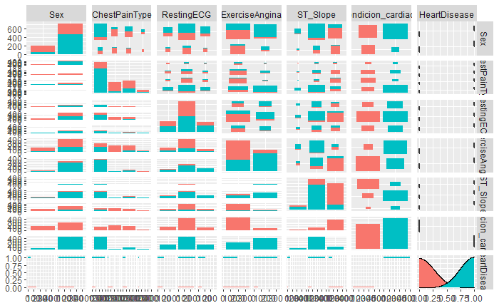

```r
df %>% select(where(is.character) | HeartDisease) %>% ggpairs(aes(color=condicion_cardiaca),  progress = FALSE)
```

```r
set.seed(42)
partes <- createDataPartition(df$HeartDisease, p=0.8, list= FALSE)
train_df <-df[partes,]
test_df <-df[-partes,]
```

## Regresion Logistica

```r
## Entrenamos un modelo de regresion logistica sobre los datos de train

train_df_lr <- train_df
train_df_lr$HeartDisease <- as.factor(train_df_lr$HeartDisease)
model_lr <- train(HeartDisease~., train_df_lr %>% select(-condicion_cardiaca), method = 'glm')
```

```r
summary(model_lr)
```

```
Call:
NULL

Deviance Residuals:
    Min       1Q   Median       3Q      Max
-2.5029  -0.3976   0.1748   0.4576   2.4379

Coefficients:
                  Estimate Std. Error z value Pr(>|z|)
(Intercept)      -0.875236   1.540713  -0.568 0.569986
Age               0.011780   0.014617   0.806 0.420314
SexM              1.321462   0.303304   4.357 1.32e-05 ***
ChestPainTypeATA -1.753903   0.347647  -5.045 4.53e-07 ***
ChestPainTypeNAP -1.576952   0.290080  -5.436 5.44e-08 ***
ChestPainTypeTA  -1.441721   0.469070  -3.074 0.002115 **
RestingBP         0.008504   0.006605   1.288 0.197920
Cholesterol      -0.003449   0.001206  -2.861 0.004226 **
FastingBS         1.150872   0.303332   3.794 0.000148 ***
RestingECGNormal -0.290318   0.305888  -0.949 0.342570
RestingECGST     -0.469533   0.393670  -1.193 0.232984
MaxHR            -0.006829   0.005522  -1.237 0.216224
ExerciseAnginaY   0.672070   0.272506   2.466 0.013653 *
Oldpeak           0.328863   0.131760   2.496 0.012563 *
ST_SlopeFlat      1.296459   0.488665   2.653 0.007976 **
ST_SlopeUp       -1.094016   0.516590  -2.118 0.034195 *
---
Signif. codes:  0 ‘***’ 0.001 ‘**’ 0.01 ‘*’ 0.05 ‘.’ 0.1 ‘ ’ 1

(Dispersion parameter for binomial family taken to be 1)

    Null deviance: 1016.17  on 734  degrees of freedom
Residual deviance:  496.68  on 719  degrees of freedom
AIC: 528.68

Number of Fisher Scoring iterations: 5
```

## LIME

```r
## usamos LIME para generar un explicador, a partir de los datos y del modelo


# Create an explainer object
explainer_lr <- lime(train_df_lr, model_lr)
```

Generamos la explicación de las predicciones, con la función explain y el ‘explicador’ antes generado Los parametros mas importantes son:

- n_labels –> Para el caso de clasificadores con mas de una label, se seleccionan la cantidad que se busca explicar, en nuestro caso solo 1
- n_features –> La cantidad de features por observacion a explicar

```r
## Generamos las explicaciones para cada observacion del dataset de test
test_df_lr <- test_df
test_df_lr$HeartDisease <- as.factor(test_df_lr$HeartDisease)

# explain lr
explanation_lr <- explain(test_df_lr, explainer_lr, n_labels = 1, n_features = 3)
```

El resultado es un dataframe que nos muestra la explicacion generada para observacion:

- model_type, corresponde al tipo de modelo utilizado
- case: indica el nombre de la observacion
- label: el label que esta siendo explicado
- label_prob:
- model_r2: La calidad del modelo generado para la explicacion
- model_intercept: El intercept del modelo generado para la explicacion
- model_prediction: La prediccion generada por el modelo explicativo para la observacion
- Feature: La Feature usada para la explicacion
- Feature_weight: El peso asignado a la feature al modelo explicativo
- data: Data original de la observacion
- prediction: Prediccion original de la observacion

```r
explanation_lr
```

| model_type | case | label | label_prob | model_r2 | model_intercept | model_prediction | feature | feature_value | feature_weight | feature_desc | data | prediction |
| --- | --- | --- | --- | --- | --- | --- | --- | --- | --- | --- | --- | --- |
| classification | 1 | 0 | 0.8917853 | 0.5404591 | 0.451854163 | 0.8047685 | ST_Slope | Up | 0.38458291 | ST_Slope = Up |  |  |
| classification | 1 | 0 | 0.8917853 | 0.5404591 | 0.451854163 | 0.8047685 | Oldpeak | 0 | 0.17257760 | Oldpeak <= 0.0 |  |  |
| classification | 1 | 0 | 0.8917853 | 0.5404591 | 0.451854163 | 0.8047685 | Sex | M | -0.20424616 | Sex = M |  |  |
| classification | 2 | 0 | 0.9666047 | 0.5187399 | 0.470722860 | 0.8021651 | ST_Slope | Up | 0.37052829 | ST_Slope = Up |  |  |
| classification | 2 | 0 | 0.9666047 | 0.5187399 | 0.470722860 | 0.8021651 | Oldpeak | 0 | 0.16122488 | Oldpeak <= 0.0 |  |  |
| classification | 2 | 0 | 0.9666047 | 0.5187399 | 0.470722860 | 0.8021651 | Sex | M | -0.20031093 | Sex = M |  |  |
| classification | 3 | 0 | 0.9853187 | 0.5299528 | 0.250291453 | 1.0006173 | ST_Slope | Up | 0.37396245 | ST_Slope = Up |  |  |
| classification | 3 | 0 | 0.9853187 | 0.5299528 | 0.250291453 | 1.0006173 | Oldpeak | 0 | 0.17825789 | Oldpeak <= 0.0 |  |  |
| classification | 3 | 0 | 0.9853187 | 0.5299528 | 0.250291453 | 1.0006173 | Sex | F | 0.19810547 | Sex = F |  |  |
| classification | 4 | 0 | 0.9901101 | 0.5292668 | 0.293511225 | 1.0532365 | ST_Slope | Up | 0.37924973 | ST_Slope = Up |  |  |

[output cut: 539 more lines]

```r
## notar que case corresponde con el rowname en el datafame de test utilizado
```

```r
unique(explanation_lr$feature)
```

```
[1] "ST_Slope"       "Oldpeak"        "Sex"            "ChestPainType"  "Cholesterol"    "RestingBP"      "ExerciseAngina"
```

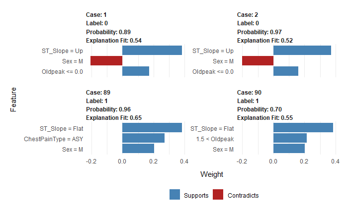

```r
plot_features(explanation_lr, case= c(1,2,90, 89))
```

```r
##genero predicciones sobre el dataset de test
predicted_lr <-predict(model_lr, test_df_lr)
test_df_lr$predicted <- predicted_lr
## agrego una columna que indique si la prediccion fue un acierto o no, util para graficar mas adelante
test_df_lr <- test_df_lr %>% mutate(Aciertos = HeartDisease == predicted)
```